# Projet ENSAssuRances - Analyse des risques automobiles

## 4.4 L’option “Petit Rouleur”

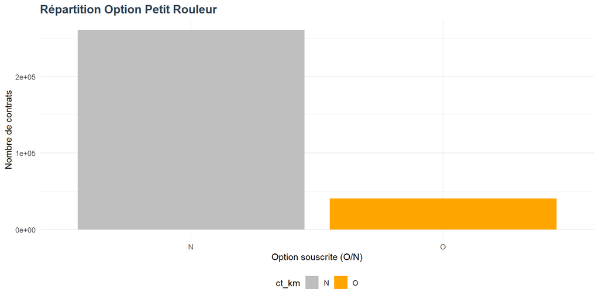

```r
# Histogramme des contrats avec ou sans option petit rouleur
ggplot(df_final, aes(x = ct_km, fill = ct_km)) +
  geom_bar() +
  scale_fill_manual(values = c("gray", "orange")) +
  labs(title = "Répartition Option Petit Rouleur",
       x = "Option souscrite (O/N)", y = "Nombre de contrats")
```

# 5. Identification des risques élevés

Nous croisons les données pour identifier les segments déficitaires.

## 5.1 Classement des véhicules à risque élevé

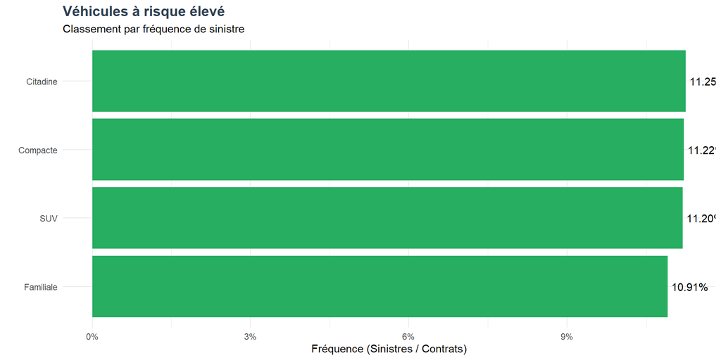

```r
# Identification des véhicules à risque élevé
# On définit le risque par la fréquence (Nb sinistres / Nb contrats)
risque_vehicule <- df_final %>%
  group_by(vh_segment) %>%
  summarise(
    nb_contrats = n(),
    nb_sinistres = sum(nb_sinistres_total),
    frequence = nb_sinistres / nb_contrats
  ) %>%
  arrange(desc(frequence))

ggplot(risque_vehicule, aes(x = reorder(vh_segment, frequence), y = frequence)) +
  geom_col(fill = "#27AE60") +
  coord_flip() +
  geom_text(aes(label = percent(frequence, 0.01)), hjust = -0.1) +
  labs(title = "Véhicules à risque élevé",
       subtitle = "Classement par fréquence de sinistre",
       x = "", y = "Fréquence (Sinistres / Contrats)") +
  scale_y_continuous(labels = percent)
```

**Analyse de la fréquence par segment** : L’analyse révèle une homogénéité de la fréquence de sinistre entre les principaux segments : Citadines, Compactes et SUV affichent tous un taux proche de 11,2%. Seul le segment Familiale se distingue par une sinistralité légèrement plus faible avec un taux à 10,91%. Cette quasi-égalité implique que le segment commercial n’est pas un levier pertinent pour segmenter le risque fréquence. La différenciation tarifaire entre ces véhicules devra donc reposer essentiellement sur le coût moyen des réparations et non sur la probabilité d’accident.